# masterclass_dataviz_crowdfunding_correction

<img src="https://datascientest.fr/train/assets/logo_datascientest.png", style="height:150px">

<h1 style = "text-align:center" > MasterClass DataViz </h1>

<h2 style = "text-align:center"> Analyser la réussite d'une campagne de *crowdfunding* </h2>

> Lor de cette Masterclass nous travaillerons sur des données provenant d'une plateforme de financement participatif (*Kickstarter*), qui donne la possibilité aux internautes de financer des projets encore au stade d'idée, en réduisant les inconvénients associées aux modes traditionnels d'investissement.

> La plateforme fonctionne comme suit : un créateur de projet fixe un objectif de collecte de fonds, une date limite, et définit des récompenses pour ses investisseurs éventuels. Si l'objectif est atteint avant la date limite, le paiement des invetisseurs est déclenché et ces derniers reçoivent leurs cadeaux. Si l'objectif n'est pas atteint, personne ne paye.

> L'objectif de cette masterclass est d'effectuer une première analysevisuelle du jeu de données fourni, en amont de la création d'un modèle de classification permettant de prédire si un projet va parvenir à récolter les fonds nécessaires avant la date limite.

```python
## Insérez votre code ici
```

```python
# les bibliothèques
import numpy as np
import pandas as pd
import matplotlib.pyplot as plt
import seaborn as sns
sns.set(style="white")

# pour éviter d'afficher les graphes sur une autre fenêtre
%matplotlib inline

df= pd.read_csv("ks-projects-201801.csv")
```

> Le data set df contient 378 661 observations.
> - Afficher les cinq premières lignes du DataFrame **df**?
> - Afficher les informations du DataFrame **df**?

```python
print(df.info())
df.head()
```

```
<class 'pandas.core.frame.DataFrame'>
RangeIndex: 378661 entries, 0 to 378660
Data columns (total 15 columns):
ID                  378661 non-null int64
name                378657 non-null object
category            378661 non-null object
main_category       378661 non-null object
currency            378661 non-null object
deadline            378661 non-null object
goal                378661 non-null float64
launched            378661 non-null object
pledged             378661 non-null float64
state               378661 non-null object
backers             378661 non-null int64
country             378661 non-null object
usd pledged         374864 non-null float64
usd_pledged_real    378661 non-null float64
usd_goal_real       378661 non-null float64
dtypes: float64(5), int64(2), object(8)
memory usage: 43.3+ MB
None
```

|  | ID | name | category | main_category | currency | deadline | goal | launched | pledged | state | backers | country | usd pledged | usd_pledged_real | usd_goal_real |
| --- | --- | --- | --- | --- | --- | --- | --- | --- | --- | --- | --- | --- | --- | --- | --- |
| 0 | 1000002330 | The Songs of Adelaide & Abullah | Poetry | Publishing | GBP | 2015-10-09 | 1000.0 | 2015-08-11 12:12:28 | 0.0 | failed | 0 | GB | 0.0 | 0.0 | 1533.95 |
| 1 | 1000003930 | Greeting From Earth: ZGAC Arts Capsule For ET | Narrative Film | Film & Video | USD | 2017-11-01 | 30000.0 | 2017-09-02 04:43:57 | 2421.0 | failed | 15 | US | 100.0 | 2421.0 | 30000.00 |
| 2 | 1000004038 | Where is Hank? | Narrative Film | Film & Video | USD | 2013-02-26 | 45000.0 | 2013-01-12 00:20:50 | 220.0 | failed | 3 | US | 220.0 | 220.0 | 45000.00 |
| 3 | 1000007540 | ToshiCapital Rekordz Needs Help to Complete Album | Music | Music | USD | 2012-04-16 | 5000.0 | 2012-03-17 03:24:11 | 1.0 | failed | 1 | US | 1.0 | 1.0 | 5000.00 |
| 4 | 1000011046 | Community Film Project: The Art of Neighborhoo... | Film & Video | Film & Video | USD | 2015-08-29 | 19500.0 | 2015-07-04 08:35:03 | 1283.0 | canceled | 14 | US | 1283.0 | 1283.0 | 19500.00 |

- Supprimer les variables inutiles

```python
df=df.drop(['pledged','usd pledged','goal', 'ID'], axis=1)
```

- Afficher les statistiques décriptives des variables numérique.

```python
df.describe()
```

|  | backers | usd_pledged_real | usd_goal_real |
| --- | --- | --- | --- |
| count | 378661.000000 | 3.786610e+05 | 3.786610e+05 |
| mean | 105.617476 | 9.058924e+03 | 4.545440e+04 |
| std | 907.185035 | 9.097334e+04 | 1.152950e+06 |
| min | 0.000000 | 0.000000e+00 | 1.000000e-02 |
| 25% | 2.000000 | 3.100000e+01 | 2.000000e+03 |
| 50% | 12.000000 | 6.243300e+02 | 5.500000e+03 |
| 75% | 56.000000 | 4.050000e+03 | 1.550000e+04 |
| max | 219382.000000 | 2.033899e+07 | 1.663614e+08 |

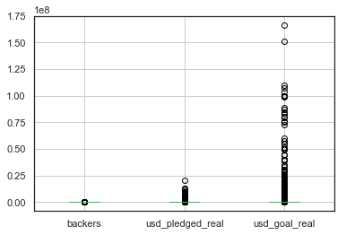

```python
df.boxplot()
```

- Combien y a-t-il eu de campagnes par catégories principales?

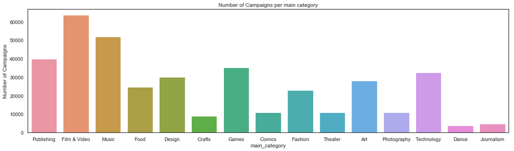

```python
plt.subplots(figsize=(19,5))
sns.countplot(x="main_category",data=df)
plt.ylabel("Number of Campaigns")
plt.title("Number of Campaigns per main category");
```

- Transformer les variables **`deadline`** et **`launched`** en format date (date uniquement).
- Calculer dans une variable **`length_days`**, la différence, en jours, entre ces deux dates.
- Ajouter une variable **`launch_year`** contenant l'année de lancement de la campagne.

```python
df['deadline']=pd.to_datetime(df['deadline'], format="%Y/%m/%d").dt.date
df['launched']=pd.to_datetime(df['launched'], format="%Y/%m/%d").dt.date

df['length_days'] = (df['deadline'] - df['launched']).dt.days

df['launch_year']=pd.to_datetime(df['launched'], format="%Y/%m/%d").dt.year
df["launch_year"]=df['launch_year'].apply(str)
```

- Combien y a-t-il eu de campagnes par an?

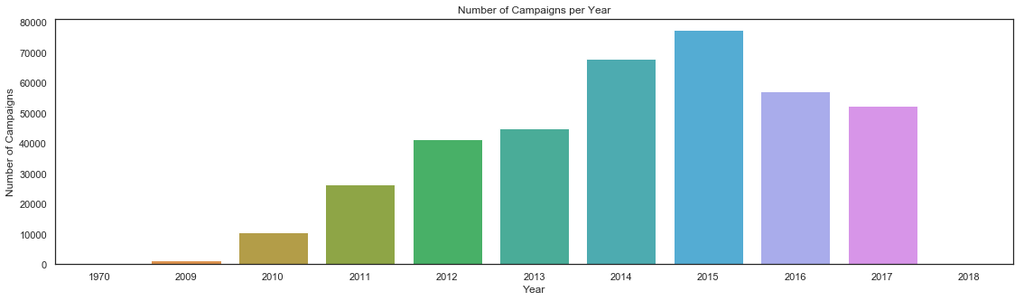

```python
plt.subplots(figsize=(19,5))
sns.countplot(df.launch_year)
plt.xlabel("Year")
plt.ylabel("Number of Campaigns")
plt.title("Number of Campaigns per Year");
```

- Visualiser la distribution de la variable **`state`**.

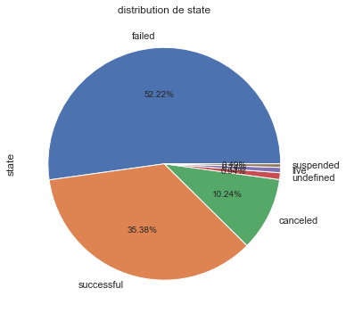

```python
(df['state'].value_counts()/len(df['state'])).plot.pie(autopct='%.2f%%' ,title='distribution de state',figsize=(6,6));
```

- Transformer les modalités autres que `successful` et `failed` en **`other`**.

```python
df.state[df.state.isin(['suspended','live', 'undefined', 'canceled'])] = 'other'
```

- Revisualiser la distribution de **`state`**.

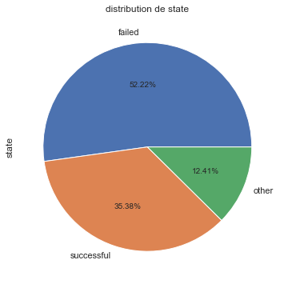

```python
(df['state'].value_counts()/len(df['state'])).plot.pie(autopct='%.2f%%' ,title='distribution de state',figsize=(6,6));
```

- Par catégorie principale, combien de campagnes ont réussi/échoué ou autre ?

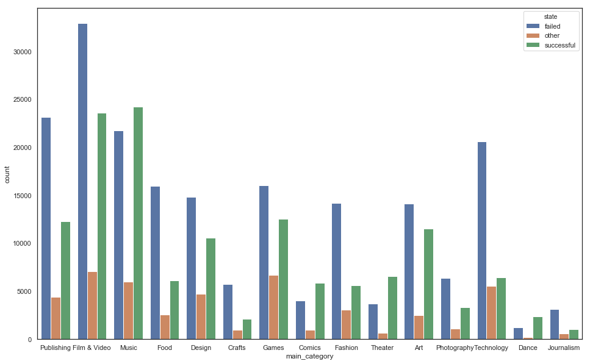

```python
plt.figure(figsize=(16,10))
sns.countplot(x="main_category", hue = 'state', data=df);
```

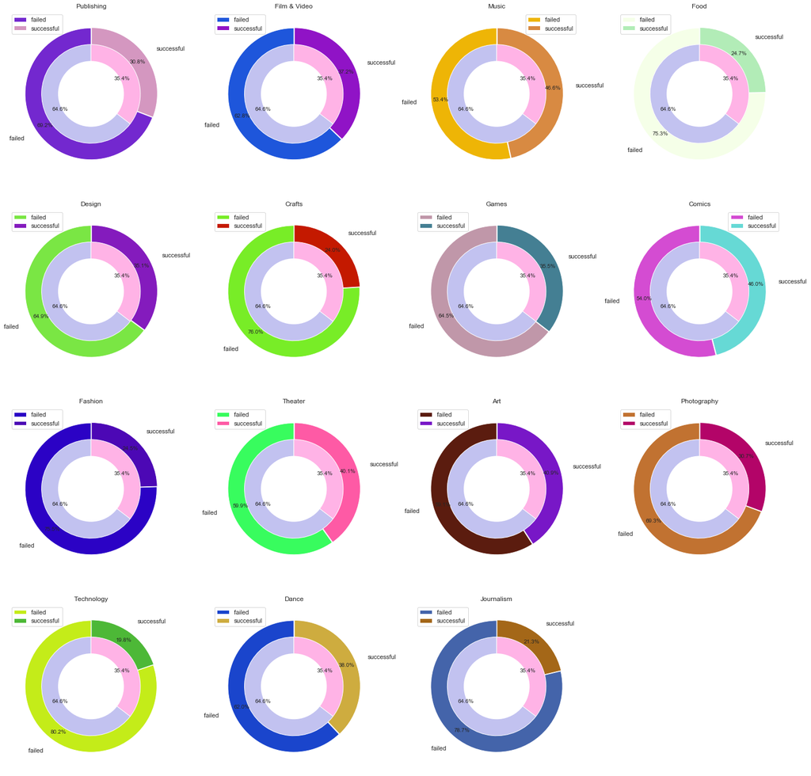

```python
df.state[df.state == 'other'] = 'failed'
import random
import matplotlib.cm as cm
arr = df.main_category.drop_duplicates()
i=1
fig = plt.figure(figsize = (25, 25))
for x in arr :
    xLabel=['failed ','successful']
    xColors= [(random.random(),random.random(),random.random()),(random.random(),random.random(),random.random())]
    xDist=[0., 0.01]
    fig.add_subplot(4,4,i)
    plt.pie(df[(df.main_category==x)].state.value_counts(), frame=True, labels = xLabel, colors=xColors, pctdistance=0.85, autopct='%1.1f%%',labeldistance=1.2, explode=xDist, startangle=90)
    plt.title(x)
    plt.legend(loc='best');
    plt.pie(df.state.value_counts(), colors=['#c2c2f0','#ffb3e6'], radius=0.75, startangle=90, pctdistance=0.70, autopct='%1.1f%%')
    centre_circle = plt.Circle((0,0),0.5,color='black', fc='white',linewidth=0)
    fig = plt.gcf()
    fig.gca().add_artist(centre_circle)
    i+=1;
```

- Visualiser en détail la distribution des catégories à l'intérieur de chacune des 3 catégories principales.

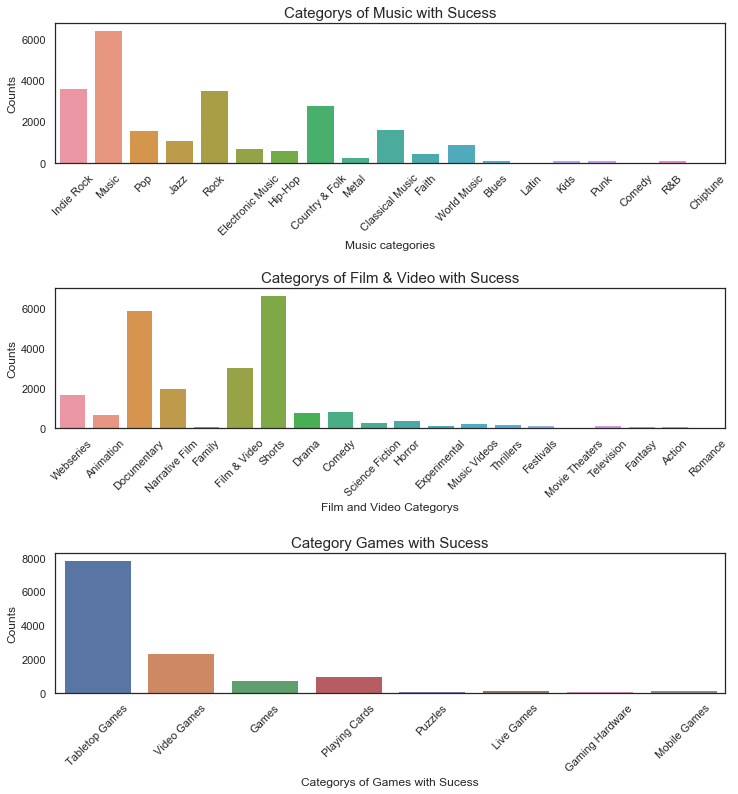

```python
sucess_music = df[(df['main_category'] == 'Music') &
                      (df['state'] == 'successful')]
sucess_film_video = df[(df['main_category'] == 'Film & Video') &
                      (df['state'] == 'successful')]
sucess_games = df[(df['main_category'] == 'Games') &
                      (df['state'] == 'successful')]

plt.figure(figsize=(12,12))

plt.subplot(3,1,1)
ax0 = sns.countplot(x='category', data=sucess_music)
ax0.set_xticklabels(ax0.get_xticklabels(),rotation=45)
ax0.set_title("Categorys of Music with Sucess", fontsize=15)
ax0.set_xlabel("Music categories", fontsize=12)
ax0.set_ylabel("Counts", fontsize=12)

plt.subplot(3,1,2)
ax1 = sns.countplot(x='category', data=sucess_film_video)
ax1.set_xticklabels(ax1.get_xticklabels(),rotation=45)
ax1.set_title("Categorys of Film & Video with Sucess", fontsize=15)
ax1.set_xlabel("Film and Video Categorys", fontsize=12)
ax1.set_ylabel("Counts", fontsize=12)

plt.subplot(3,1,3)
ax2 = sns.countplot(x='category', data=sucess_games)
ax2.set_xticklabels(ax2.get_xticklabels(),rotation=45)
ax2.set_title("Category Games with Sucess", fontsize=15)
ax2.set_xlabel("Categorys of Games with Sucess", fontsize=12)
ax2.set_ylabel("Counts", fontsize=12)

plt.subplots_adjust(wspace = 0.3, hspace = 0.9,top = 0.9)

plt.show()
```

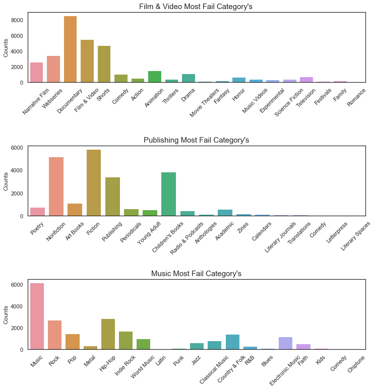

```python
failed_film = df[(df['main_category'] == 'Film & Video') &
                      (df['state'] == 'failed')]
failed_publishing = df[(df['main_category'] == 'Publishing') &
                      (df['state'] == 'failed')]
failed_music = df[(df['main_category'] == 'Music') &
                      (df['state'] == 'failed')]

plt.figure(figsize=(12,12))

plt.subplot(3,1,1)
ax0 = sns.countplot(x='category', data=failed_film)
ax0.set_xticklabels(ax0.get_xticklabels(),rotation=45)
ax0.set_title("Film & Video Most Fail Category's ", fontsize=15)
ax0.set_xlabel("", fontsize=12)
ax0.set_ylabel("Counts", fontsize=12)

plt.subplot(3,1,2)
ax1 = sns.countplot(x='category', data=failed_publishing)
ax1.set_xticklabels(ax1.get_xticklabels(),rotation=45)
ax1.set_title("Publishing Most Fail Category's", fontsize=15)
ax1.set_xlabel("", fontsize=12)
ax1.set_ylabel("Counts", fontsize=12)

plt.subplot(3,1,3)
ax2 = sns.countplot(x='category', data=failed_music)
ax2.set_xticklabels(ax2.get_xticklabels(),rotation=45)
ax2.set_title("Music Most Fail Category's", fontsize=15)
ax2.set_xlabel("", fontsize=12)
ax2.set_ylabel("Counts", fontsize=12)

plt.subplots_adjust(wspace = 0.5, hspace = 0.9,top = 0.9)
plt.show()
```

- Y a-t-il un rapport entre la durée de la campagne et sa réussite?

[figure not shown]

```python
df.groupby('state')['length_days'].mean().plot.bar();
plt.title("Average days length by state");
```

- Combien de temps durent les campagnes réussies à l'intérieur des différentes catégories principales?

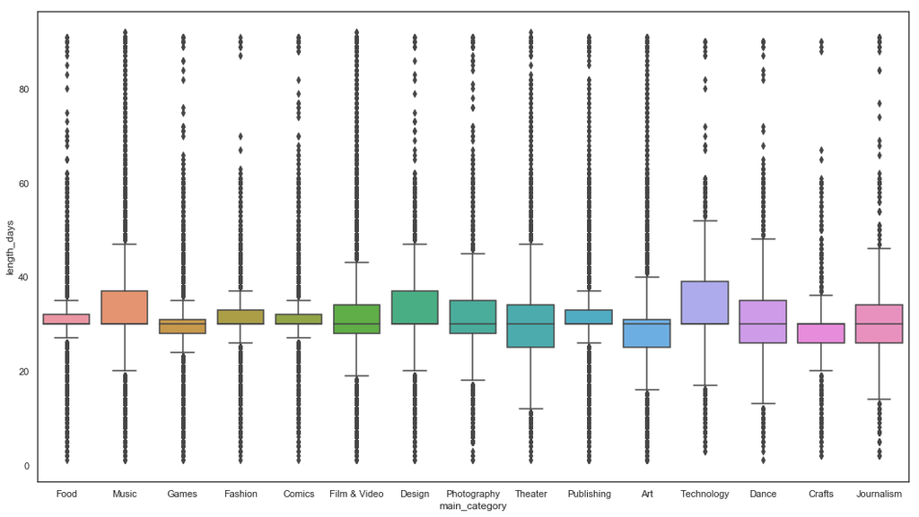

```python
plt.figure(figsize=(18,10))
sns.boxplot(x = 'main_category', y = 'length_days', data=df[df.state=='successful']);
```

- Quelles sont les 15 campagnes ayant obtenu le plus de fonds? A quelles catégories appartiennent-elles?

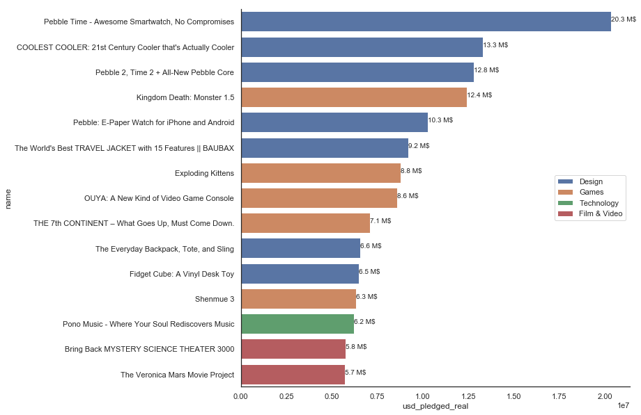

```python
top15 =df.sort_values('usd_pledged_real', ascending=False)[['name','usd_pledged_real', 'main_category']].head(15)
top15.index= top15.name
fig = plt.figure(figsize=(10,10))
sns.barplot(y= 'name', x= 'usd_pledged_real', data=top15, hue = 'main_category', dodge=False)
sns.despine()
for i in range(15):
    plt.text(top15.usd_pledged_real[i], i, "%.1f M$" %(top15.usd_pledged_real[i]/1000000))
plt.legend(loc = 'center right');
```

- Quelles sont les 15 campagnes ayant récolté le plus de fonds supplémentaires à ceux nécessaires?

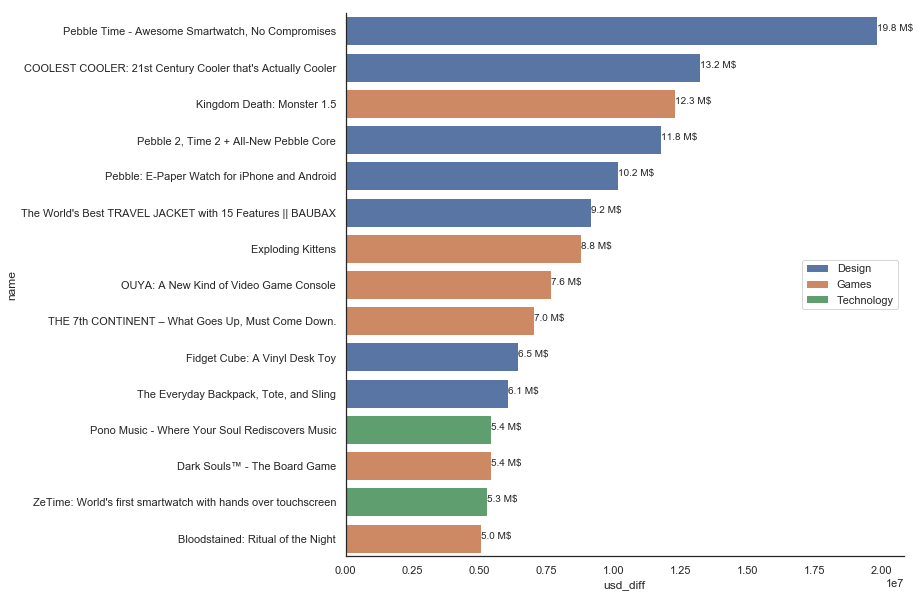

```python
df['usd_diff']=  df.usd_pledged_real - df.usd_goal_real

top_diff =df.sort_values('usd_diff', ascending=False)[['name','usd_diff', 'main_category']].head(15)
top_diff.index= top_diff.name

fig = plt.figure(figsize=(10,10))
sns.barplot(y= 'name', x= 'usd_diff', data=top_diff, hue = 'main_category', dodge=False)
sns.despine()
for i in range(15):
    plt.text(top_diff.usd_diff[i], i, "%.1f M$" %(top_diff.usd_diff[i]/1000000) )
plt.legend(loc = 'center right');
```

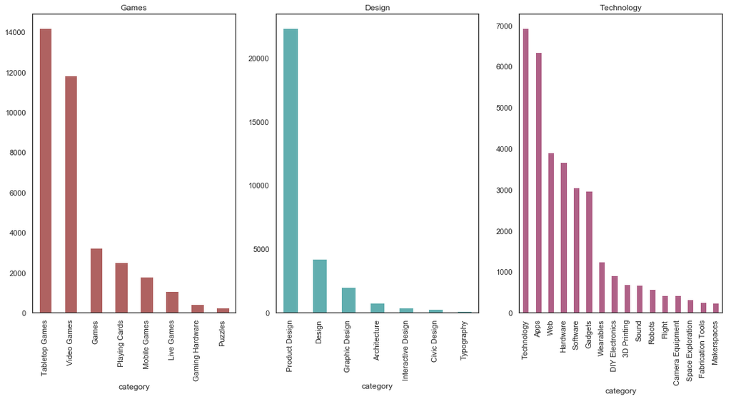

```python
fig = plt.figure(figsize=(18,8))
ax1 = fig.add_subplot(131)
ax2 = fig.add_subplot(132)
ax3 = fig.add_subplot(133)

df_games= df[df.main_category == 'Games']
df_games.groupby('category').size().sort_values(ascending=False).plot(kind='bar', color='#AF6261', ax=ax1, title = 'Games')

df_design = df[df.main_category == 'Design']
df_design.groupby('category').size().sort_values(ascending=False).plot(kind='bar', color='#61aeaf',ax=ax2, title = 'Design')

df_techno = df[df.main_category == 'Technology']
df_techno.groupby('category').size().sort_values(ascending=False).plot(kind='bar', color='#af6187',ax=ax3, title = 'Technology');
```

- Afficher le goal moyen et la durée moyenne des campagnes fructueuse de chaque catégorie

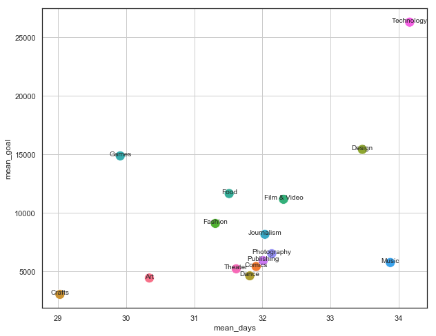

```python
df_mean = df[df.state=='successful'].groupby("main_category").mean().reset_index()[['main_category','usd_goal_real','length_days']]
df_mean.set_axis(['main_cat', 'mean_goal', 'mean_days'], axis='columns',inplace=True)
plt.figure(figsize =(10,8))
sns.scatterplot(y="mean_goal", x="mean_days", hue= 'main_cat', data= df_mean, s= 200, legend=False)
plt.grid()
for i in range(len(df_mean)):
    plt.text( df_mean.iloc[i,2], df_mean.iloc[i,1], df_mean.iloc[i,0],  ha='center')
```

- Quels sont les monnaies / les pays d'origine les plus impliqués dans les campagnes réussies?

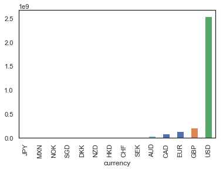

```python
df[df.state=='successful'].groupby('currency').sum()['usd_pledged_real'].sort_values().plot.bar();
```

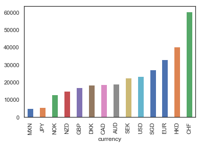

```python
df[df.state=='successful'].groupby('currency').mean()['usd_pledged_real'].sort_values().plot.bar();
```

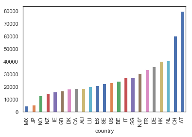

```python
df[df.state=='successful'].groupby('country').mean()['usd_pledged_real'].sort_values().plot.bar();
```

- Quel est le montant moyen investi par *backer* et par catégorie?

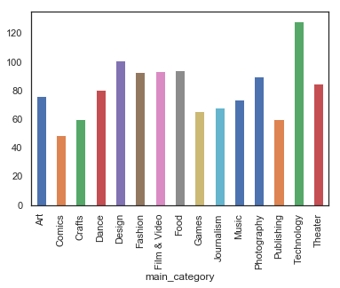

```python
df.groupby('main_category').apply(lambda df : sum(df.usd_pledged_real)/sum(df.backers)).plot.bar();
```

- Quel est le nombre de campagne à succès / ratée par an?

```python
df2 = df[df['state']=='successful'].groupby('launch_year', as_index = False).count().rename(columns = {'state' : 'Number of success'})

df3 = df[df['state']=='failed'].groupby('launch_year', as_index = False).count().rename(columns = {'state' : 'Number of failed'})
```

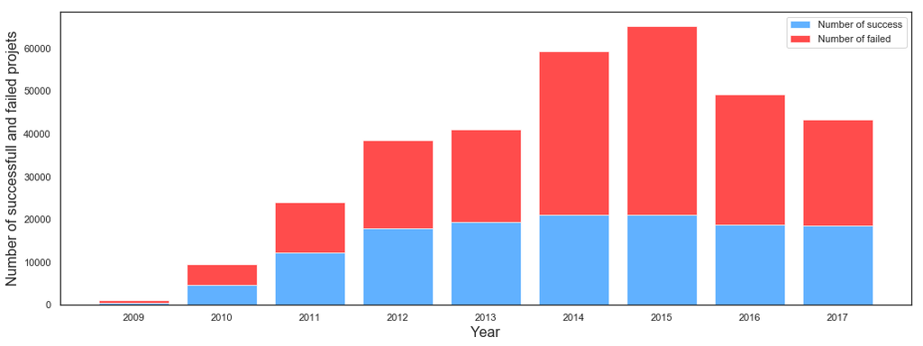

```python
plt.figure(figsize=(17,6))

plt.bar(df2['launch_year'], df2['Number of success'], label = 'Number of success', color = 'dodgerblue', align = 'center', alpha = 0.7)
plt.bar(df2['launch_year'], df3['Number of failed'], label = 'Number of failed', color = 'red',bottom=df2['Number of success'], align = 'center', alpha = 0.7)

plt.xlabel('Year', fontsize = 16)
plt.ylabel('Number of successfull and failed projets', fontsize = 16)

plt.legend();
```

- Afficher la matrice des corrélations entre les variables

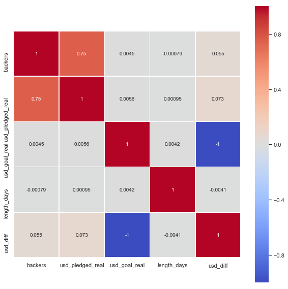

```python
corr = df.corr()
# Set up the matplotlib figure
f, ax = plt.subplots(figsize=(10, 10))
sns.heatmap(corr, annot=True,  cmap='coolwarm',  center=0,
            square=True, linewidths=.5)
```

- Afficher l'histogramme de la distribution de la variable **`usd_pledged_real`**.

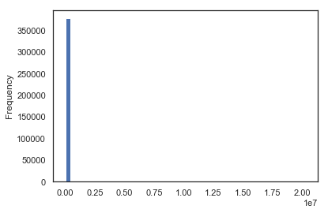

```python
df['usd_pledged_real'].plot(kind='hist', bins = 50)
```

- Que constatez-vous?
- Afin de mieux visualiser les relations entre les variables appliquons une transformation Log(x+1) aux variables numériques.

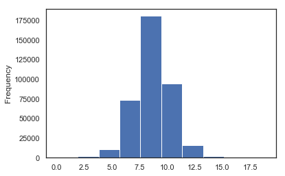

```python
df["usd_pledged_real"]=df["usd_pledged_real"].apply(lambda x: np.log(x+1))
df["usd_goal_real"]=df["usd_goal_real"].apply(lambda x: np.log(x+1))
df["backers"]=df["backers"].apply(lambda x: np.log(x+1))
df['usd_goal_real'].plot(kind='hist')
```

- Afficher les relations entres les variables `'usd_goal_real',"usd_pledged_real",'backers',"length_days"`, en fonction de la réussite ou non des projets.

[figure not shown]

```python
sns.pairplot(df[['usd_goal_real',"usd_pledged_real",'backers',"length_days","state"]] , hue="state")
```